# Diagnosis and Suggestive Treatment of Heart Disease Using Statistical Machine Learning

### Defining the Necessary Functions to Implement Gradient Descent

We separate out different components of the gradient descent algorithm in smaller, easier to understand functions. This helps to make the code more readable and easier to debug. We first define the methods `logistic_func`, `logistic_loss`, and `gradients` based on the mathematical derivations found above.

```r
# s-shaped sigmoid function
logistic_func <- function(logits) {
    1/(1 + exp(-logits))
}

# implemented using L2 ridge regularization (note: the intercept term does not get penalized)
logistic_loss <- function(betas, X, y, lambda) {
    # note that `y_hats` are the predicted conditional probabilities having applied the sigmoid function on the design matrix and coefficients product NOT the predicted
    # classes of heart disease presence
    y_hats <- logistic_func(X %*% betas)
    penalty <- lambda * sum(betas[-1] * betas[-1])

    -sum(y * log(y_hats) + (1 - y) * log(1 - y_hats)) + penalty
}

# this function is not a numeric approximation of the gradient but rather the direct analytical
# functional form as derived in the mathematics above
gradients <- function(betas, X, y, lambda) {
    # note that `y_hats` are the predicted conditional probabilities having applied the sigmoid function on the design matrix and coefficients product NOT the predicted
    # classes of heart disease presence
    y_hats <- logistic_func(X %*% betas)

    # separate the logistic and penalty terms to compute gradients easier
    logistic_gradient <- t(X) %*% (y_hats - y)
    penalty_gradient <- 2 * lambda * betas[-1]

    # sum the two components of the gradient while keeping the intercept term non-regularized
    logistic_gradient + c(0, penalty_gradient)
}
```

The baseline helper functions are now defined to be used later on. Our implementation requires that the input space be a matrix $\boldsymbol{X}$ of a specific format which `design_matrix` forces data to conform to.

The `update_step_size` uses the Barzilai-Borwein (BB) method for updating how big the gradient should move (its step size) each iteration of the descent based on the two previous estimated coefficients and gradients. We settled on using BB to help the model more dynamically converge without setting an arbitrary learning rate.

Finally, the `gradient_descent` function uses all of the previously defined methods to run logistic gradient descent given some tuning parameters (such as learning rate and lambda) and returns histories of the coefficients, gradients, losses, step sizes, and predictor names to enable the tracking of how the gradient descent function converges to the minimum of the loss function.

```r
# format the training dataset by removing the target column, adding an intercept
# column of all 1s, and scaling the inputs before returning it as a matrix
# (necessary for the %*% notation used)
design_matrix <- function(training) {
    training %>%
        select(-c(all_of("target"))) %>%
        mutate(intercept = 1, .before = 1) %>%
        mutate_at(vars(-intercept), scale) %>%
        as.matrix
}

# returns the optimal step size as computed by the Barzilai-Borwein method given
# the current and previous beta and gradient
update_step_size <- function(iteration, betas, gradients) {
    betas_delta <- betas[iteration - 1,] - betas[iteration - 2,]
    gradients_delta <- gradients[iteration - 1,] - gradients[iteration - 2,]

    # we have found that taking long BB step sizes works better for these data
    sum(betas_delta %*% betas_delta) / sum(betas_delta %*% gradients_delta)
}

gradient_descent <- function(training, predictor_names, lambda, tolerance, max_iterations) {
    # format the X and y training values to be of use
    X_training <- design_matrix(training)
    y_training <- training$target

    # randomly sample `p` uniformly-distributed values for the initial coefficients
    # since the inputs are scaled in the range [0,1]
    initial_betas <- runif(ncol(X_training))
    initial_step_size <- runif(1, min = 0.001, max = 0.01)

    # each value is an iteration of updated losses to keep track of its history;
    # the same goes for the step sizes
    losses <- numeric(max_iterations)
    step_sizes <- numeric(max_iterations)

    # each row is an iteration of updated coefficients to keep track of its history;
    # the same goes for the gradients
    betas <- matrix(NA, nrow = max_iterations, ncol = ncol(X_training))
    gradients <- matrix(NA, nrow = max_iterations, ncol = ncol(X_training))

    # save the initial coefficients as the randomly selected ones and manually
    # kickstart the descent algorithm
    betas[1,] <- initial_betas
    gradients[1,] <- gradients(betas[1,], X_training, y_training, lambda)
    step_sizes[1] <- initial_step_size
    losses[1] <- logistic_loss(betas[1,], X_training, y_training, lambda)

    # another iteration of manually computing the descent algorithm to ensure
    # that it is working before looping through
    betas[2,] <- betas[1,] - step_sizes[1] * gradients[1,]
    gradients[2,] <- gradients(betas[2,], X_training, y_training, lambda)
    step_sizes[2] <- initial_step_size
    losses[2] <- logistic_loss(betas[2,], X_training, y_training, lambda)

    for(iteration in 3:max_iterations) {
        previous_beta <- betas[iteration - 1,]
        previous_gradient <- gradients[iteration - 1,]
        previous_step_size <- step_sizes[iteration - 1]

        # compute the optimal step size using the Barzilai-Borwein method and then
        # update the coefficients, gradients, and losses
        step_sizes[iteration] <- update_step_size(iteration, betas, gradients)
        betas[iteration,] <- previous_beta - step_sizes[iteration] * previous_gradient
        gradients[iteration,] <- gradients(betas[iteration,], X_training, y_training, lambda)
        losses[iteration] <- logistic_loss(betas[iteration,], X_training, y_training, lambda)

        # we compute the norm, or size of, the gradient vector using the L2 norm
        # (Euclidean norm) and check if it is reasonably small enough
        if (norm(gradients[iteration,], type = "2") < tolerance) {
            # trim the betas, gradients, losses, and step sizes matrices/vectors
            # as to not have a bunch of trailing zeros or NULL values and then exit
            # the loop
            betas <- betas[1:iteration,]
            gradients <- gradients[1:iteration,]
            losses <- losses[1:iteration]
            step_sizes <- step_sizes[1:iteration]
            break
        }
    }

    # return all of the matrices and vectors used in a R list which will be
    # convenient by using the `$.` notation on the model output
    list(
        coefficients = betas,
        gradients = gradients,
        losses = losses,
        step_sizes = step_sizes,
        predictors = c("(Intercept)", predictor_names)
    )
}
```

### Explaining Why Scaling the Features Was Necessary

Note that we scale every column in the input space (besides the intercept and target columns) in the `design_matrix` function. When we ran this gradient descent algorithm on unscaled values the logistic loss broke down after the first few iterations. A deeper examination revealed that the scale of the input values could range from 126–564 mg/dL (in the case of cholesterol) whereas our response is only binary. This size difference meant that $\boldsymbol{X\beta}$ would either produce extremely large or extremely small values which would become numerically unstable once the sigmoid function was applied $\sigma(\boldsymbol{X\beta})$.

Consider if $\sigma(\boldsymbol{X\beta}) = 0$. Then, $\log(\sigma(\boldsymbol{X\beta})) = \log(0)$ which is undefined. Similarly, if $\sigma(\boldsymbol{X\beta}) = 1$ then, $\log(1-\sigma(\boldsymbol{X\beta})) = \log(0)$ which is also undefined. The output of sigmoid being exactly 0 or exactly 1 happens when the result of $\boldsymbol{X\beta}$ is numerically unstable. The `logistic_loss` method would save the current iteration’s loss as `NaN` (not a number) in the losses history every iteration. The `coefficients` and `gradients` contained large vectors meaning the descent jumped around a lot and never converged on the local minima, only stopping due to the `max_iterations` being met.

We scaled down the input space $\boldsymbol{X}$ (besides the intercept and target columns) to combat the numerical instability and our implementation works as expected.

### The Naive Model

#### Simulating Training and Testing Data for Our Naive Model

Before we run our logistic regression gradient descent implementation on our project data we want to assure that it works on simulated data. The following method executes this and we show a preview of the generated data as well as the true coefficients.

```r
simulate_data <- function(n_observations = 5000, p_predictors = 10) {
    set.seed(1)

    sparsity <- p_predictors / 2

    nonzero_betas <- runif(sparsity, min = -1, max = 1)
    true_coefficients <- c(.5, nonzero_betas, rep(0, sparsity))

    # we again generate random values from a uniform distribution to match the scale
    # of the inputs of the target dataset
    raw_data <- matrix(
        runif(n_observations * p_predictors),
        ncol = p_predictors
    )

    X_simulated <- cbind(
        rep(1, n_observations),
        raw_data
    )
    y_simulated <- rbinom(
        n = n_observations,
        size = 1,
        prob = logistic_func(X_simulated %*% true_coefficients)
    )

    # create the simulated dataset in the correct format as expected by the gradient
    # descent method; additionally create dummy predictor names using R's default V{1,...,p}
    # undefined column name notation
    simulated_dataset <- cbind(X_simulated[,-1], target = y_simulated) %>% as.data.frame
    predictor_names <- paste0("V", 1:p_predictors)

    set.seed(NULL)

    list(
        data = simulated_dataset,
        true_coefficients = true_coefficients,
        predictors = predictor_names
    )
}

p_predictors <- 4

simulated_training <- simulate_data(n_observations = 2000, p_predictors = p_predictors)
simulated_training$data %>% head
```

```
##          V1        V2         V3         V4 target
## 1 0.5728534 0.8669163 0.02728685 0.65047706      0
## 2 0.9082078 0.4377153 0.49629785 0.07465596      0
## 3 0.2016819 0.1919378 0.94735171 0.90258066      0
## 4 0.8983897 0.0822944 0.38118213 0.13293963      1
## 5 0.9446753 0.5834516 0.69821373 0.21082604      0
## 6 0.6607978 0.0703615 0.68876581 0.15516040      1
```

```r
simulated_training$true_coefficients %>% print
```

```
## [1]  0.5000000 -0.4689827 -0.2557522  0.0000000  0.0000000
```

We also will define the simulated testing/validation dataset which will be used later to evaluate the validation set accuracy of the naive model later. It is generated in a similar manner to its training counterpart.

```r
simulated_testing <- simulate_data(n_observations = 1000, p_predictors = p_predictors)
simulated_testing$data %>% head
```

```
##          V1         V2        V3        V4 target
## 1 0.5728534 0.38328339 0.8669163 0.1774016      1
## 2 0.9082078 0.95498800 0.4377153 0.3971333      0
## 3 0.2016819 0.11835658 0.1919378 0.8142270      0
## 4 0.8983897 0.03910006 0.0822944 0.9413571      1
## 5 0.9446753 0.50450503 0.5834516 0.1733499      1
## 6 0.6607978 0.57848256 0.0703615 0.3549408      0
```

```r
simulated_testing$true_coefficients %>% print
```

```
## [1]  0.5000000 -0.4689827 -0.2557522  0.0000000  0.0000000
```

#### Creating the Naive Model and Analyzing Its Outputs

We then now define our naive model by calling our `gradient_descent` implementation on the `simulated_training` object so that we can later visualize how the model performs on the testing stage and, eventually, how it performs on unseen testing data.

```r
naive_model <- gradient_descent(
    training = simulated_training$data,
    predictor_names = simulated_training$predictors,
    lambda = 1.7,
    tolerance = 1e-5,
    max_iterations = 10000
)
```

We additionally define some methods for understanding the output of our model including a table of coefficients, a plot of losses over iterations, a plot of step sizes over iterations, and a plot of coefficients over iterations.

We can now analyze what the naive model converged on for its coefficients versus the true coefficients by using the `compare_coefficients` method. This function generates a table of true (known since these were simulated) and expected coefficients with a third column being their difference to more easily view how big the difference is.

```r
compare_coefficients <- function(modelA_coefficients, modelB_coefficients, predictors, column_names) {
    # compute the difference in coefficients to more easily see how off our implementation estimates are
    # either in the case of our model versus R's `glm` version or our naive model versus the true
    # coefficients
    difference <- modelA_coefficients - modelB_coefficients

    # assemble the table and make it more readable with meaningful column and row names
    coefficients_comparison <- cbind(modelA_coefficients, modelB_coefficients, difference)
    colnames(coefficients_comparison) <- c(column_names, "difference")
    rownames(coefficients_comparison) <- predictors

    coefficients_comparison
}

naive_coefficients <- naive_model$coefficients[nrow(naive_model$coefficients),]
compare_coefficients(
    modelA_coefficients = naive_coefficients,
    modelB_coefficients = simulated_training$true_coefficients,
    predictors = c("(Intercept)", simulated_training$predictors),
    column_names = c("estimated coef.", "true coef.")
)
```

```
##             estimated coef. true coef.  difference
## (Intercept)      0.11342276  0.5000000 -0.38657724
## V1              -0.15215072 -0.4689827  0.31683195
## V2              -0.14944351 -0.2557522  0.10630869
## V3               0.03573019  0.0000000  0.03573019
## V4              -0.04513723  0.0000000 -0.04513723
```

#### Losses of the Naive Model

We can also observe the logistic loss history saved in the `naive_model` object and view it on a plot via the `plot_losses` function. Note that this method accepts a `model_type` parameter which is placed into the plot’s title for clarity so that this function can be used by both the naive and (later) the final models.

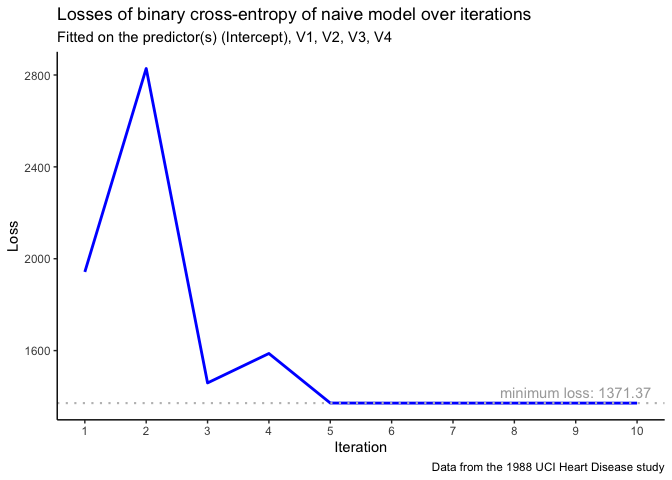

```r
plot_losses <- function(model, model_type = "normal") {
    n_iterations <- length(model$losses)
    min_loss <- min(model$losses)

    ggplot(data.frame(iteration = 1:n_iterations, loss = model$losses)) +
        # connect each loss value per iteration with a solid blue line
        geom_line(aes(x = iteration, y = loss), color = "blue", linewidth = 1) +
        # visibly show where the minimum loss achieved is and add text with the number
        geom_hline(yintercept = min_loss, linetype = "dotted", color = "gray", linewidth = 0.75) +
        annotate("text", x = n_iterations * 0.9, y = min_loss, label = paste("minimum loss:", round(min_loss, 2)), vjust = -0.5, color = "darkgray") +
        scale_x_continuous(
            limits = c(1, n_iterations),
            breaks = c(1:n_iterations)
        ) +
        # we use the parameter `model_type` since we use this same method for both our actual model
        # and the naive model
        labs(
            title = paste("Losses of binary cross-entropy of", model_type, "model over iterations"),
            subtitle = paste("Fitted on the predictor(s)", toString(model$predictors)),
            caption = "Data from the 1988 UCI Heart Disease study"
        ) +
        theme_classic() +
        theme(legend.position = "none") +
        xlab("Iteration") +
        ylab("Loss")
}

plot_losses(model = naive_model, model_type = "naive")
```

#### Changes in the Step Sizes of the Naive Model

We can additionally observe the step sizes history saved in the `naive_model` object and view it on a plot via the `plot_steps` function. It is nearly identical to `plot_losses` but with different labels and verbiage.

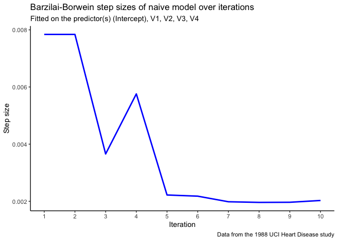

```r
plot_steps <- function(model, model_type = "normal") {
    n_iterations <- length(model$step_sizes)

    ggplot(data.frame(iteration = 1:n_iterations, step = model$step_sizes)) +
        # connect each step size value per iteration with a solid blue line
        geom_line(aes(x = iteration, y = step), color = "blue", linewidth = 1) +
        scale_x_continuous(
            limits = c(1, n_iterations),
            breaks = c(1:n_iterations)
        ) +
        labs(
            title = paste("Barzilai-Borwein step sizes of", model_type, "model over iterations"),
            subtitle = paste("Fitted on the predictor(s)", toString(model$predictors)),
            caption = "Data from the 1988 UCI Heart Disease study"
        ) +
        theme_classic() +
        theme(legend.position = "none") +
        xlab("Iteration") +
        ylab("Step size")
}

plot_steps(model = naive_model, model_type = "naive")
```

As observed above, the step size dynamically adjusts (starting large, before generally decreasing) as intended, to ensure faster convergence.

#### Changes in the Coefficients of the Naive Model

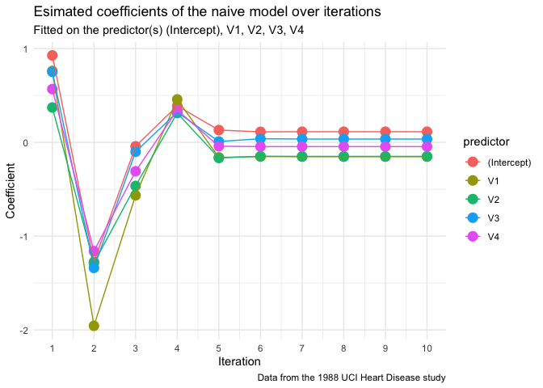

```r
plot_betas <- function(model, model_type = "normal") {
    n_iterations <- nrow(model$coefficients)

    to_plot <- data.frame(
        iteration = c(1:n_iterations),
        coefficient = as.data.frame(model$coefficients)
    )
    colnames(to_plot) <- c("iteration", model$predictors)

    # we re-shape the data so that we can connect each coefficient across iterations AND
    # show all coefficients at each snapshot via pivoting the dataframe longwise
    to_plot <- to_plot %>%
        pivot_longer(cols = -iteration, names_to = "predictor", values_to = "coefficient")

    ggplot(to_plot, aes(x = iteration, y = coefficient, color = predictor)) +
        geom_point(size = 3, stroke = 1.2) +
        geom_line() +
        scale_x_continuous(
            limits = c(1, n_iterations),
            breaks = c(1:n_iterations)
        ) +
        labs(x = "Iteration", y = "Coefficient") +
        labs(
            title = paste("Esimated coefficients of the", model_type, "model over iterations"),
            subtitle = paste("Fitted on the predictor(s)", toString(model$predictors)),
            caption = "Data from the 1988 UCI Heart Disease study"
        ) +
        theme_minimal()
}

plot_betas(model = naive_model, model_type = "naive")
```

#### Evaluating the Accuracy of the Naive Model

Having analyzed the naive model coefficients and visualized the losses and step sizes, we now seek to evaluate it by applying the `testing` subset and seeing how accurate its predictions are. We do this with the `prediction_metrics` method.

```r
as_grade <- function(raw_score) {
    # convert scores of the form 0.xxxxxxx to xx.xx for easier readability of model accuracy
    # as a percentage
    round(raw_score * 100, 2)
}

prediction_metrics <- function(model, training, testing, model_type = "normal", is_glm = FALSE) {
    # save the vectors of true classes from the training and testing subsets, respectively
    true_classes_training <- training$target
    true_classes_testing <- testing$target

    # if using the `glm` model, the inputs need to be scaled to match the inputs passed into the
    # naive and normal models AND the prediction step is different (built-in R function)
    if(is_glm) {
        r_training <- training %>% mutate_at(vars(-target), scale)
        r_testing <- testing %>% mutate_at(vars(-target), scale)

        predictions_training <- predict(model, newdata = r_training, type = "response")
        predictions_testing <- predict(model, newdata = r_testing, type = "response")
    } else {
        X_training <- design_matrix(training)
        X_testing <- design_matrix(testing)

        final_betas <- model$coefficients[nrow(model$coefficients),]

        predictions_training <- logistic_func(X_training %*% final_betas)
        predictions_testing <- logistic_func(X_testing %*% final_betas)
    }

    # convert the probabilities in `predictions_training` and `predictions_testing` into definitive
    # classifications of 0 or 1 depending on if the calculated probability p >= 0.5 or not
    prediction_classes_training <- as.vector(ifelse(predictions_training >= 0.5, 1, 0))
    prediction_classes_testing <- as.vector(ifelse(predictions_testing >= 0.5, 1, 0))

    # we use mean(...) since these are vectors of 0 and 1 so it effectively computes the accuracy;
    # we use the roc and auc methods from the pROC library
    training_accuracy <- mean(prediction_classes_training == true_classes_training)
    training_auc <- auc(roc(response = true_classes_training, predictor = prediction_classes_training))

    testing_accuracy <- mean(prediction_classes_testing == true_classes_testing)
    testing_auc <- auc(roc(response = true_classes_testing, predictor = prediction_classes_testing))

    # return all of these vectors and matrices for visualization and later analysis
    list(
        true_classes_training = true_classes_training,
        true_classes_testing = true_classes_testing,
        prediction_classes_training = prediction_classes_training,
        prediction_classes_testing = prediction_classes_testing,
        training_accuracy = as_grade(training_accuracy),
        training_auc = as_grade(training_auc),
        testing_accuracy = as_grade(testing_accuracy),
        testing_auc = as_grade(testing_auc),
        model_type = model_type
    )
}

naive_metrics <- prediction_metrics(
    model = naive_model,
    training = simulated_training$data,
    testing = simulated_testing$data,
    model_type = "naive",
    is_glm = FALSE
)
```

#### Fitting Our Normal Model and R’s glm Model

We will analyze the metrics of the naive model once we do the same with the normal model and R’s `glm` model. Now we create these model objects and examine the output of the normal model output.

```r
log_model <- gradient_descent(
    training = training,
    predictor_names = predictor_names,
    lambda = 0.0,
    tolerance = 1e-5,
    max_iterations = 10000
)

r_training <- training %>% mutate_at(vars(-target), scale)
r_model <- glm(target ~ ., family = binomial, data = r_training)
```

Because we do not know the “true coefficients” of our actual heart disease dataset we instead compare our model’s coefficients against R’s `glm` model’s coefficients to see how similar the values are. As seen in the table blow, the difference between our model and R’s coefficients are on the scale of $10^{-3}$ and smaller.

```r
log_coefficients <- log_model$coefficients[nrow(log_model$coefficients),]
compare_coefficients(
    modelA_coefficients = log_coefficients,
    modelB_coefficients = r_model$coefficients,
    predictors = log_model$predictors,
    column_names = c("model coef.", "R glm coef.")
)
```

```
##             model coef. R glm coef.    difference
## (Intercept)  -0.1932829  -0.1932829  2.937402e-09
## exang        -0.6869714  -0.6869714  2.978183e-09
## oldpeak      -1.0109913  -1.0109913  5.833574e-10
## ca           -0.8015164  -0.8015164 -1.881446e-09
## cp            0.7401933   0.7401933  1.326656e-09
```

To see the significance of the selected predictors in explaining our response, we examine the model output of `glm`. We see from the table below that `exang`, `oldpeak`, and `ca` are all statistically significant quantities.

```r
summary(r_model)
```

```
##
## Call:
## glm(formula = target ~ ., family = binomial, data = r_training)
##
## Coefficients:
##             Estimate Std. Error z value Pr(>|z|)
## (Intercept)  -0.1933     0.1046  -1.848   0.0646 .
## exang        -0.6870     0.1105  -6.216 5.11e-10 ***
## oldpeak      -1.0110     0.1322  -7.647 2.05e-14 ***
## ca           -0.8015     0.1073  -7.472 7.89e-14 ***
## cp            0.7402     0.1070   6.918 4.57e-12 ***
## ---
## Signif. codes:  0 '***' 0.001 '**' 0.01 '*' 0.05 '.' 0.1 ' ' 1
##
## (Dispersion parameter for binomial family taken to be 1)
##
##     Null deviance: 993.96  on 716  degrees of freedom
## Residual deviance: 623.68  on 712  degrees of freedom
## AIC: 633.68
##
## Number of Fisher Scoring iterations: 5
```

Specifically, the $p$-values for these coefficients we see that `exang`, `oldpeak`, and `ca` are all statistically significant predictors (all $< 0.5 = \alpha$) in explaining the presence of coronary artery disease.

Since the first two, `exang`, `oldpeak`, relate to measurements that indicate that a patient’s body does not adjust well to exercise, this may be suggestive evidence that corrective procedures might involve policies or treatments that help a patient adjust more to exercise. In other words, more physical activity might lower a patient’s risk of having CAD.

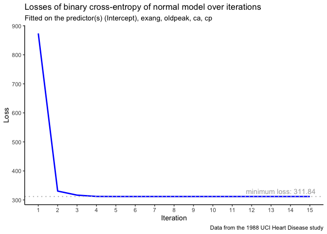

```r
plot_losses(model = log_model, model_type = "normal")
```

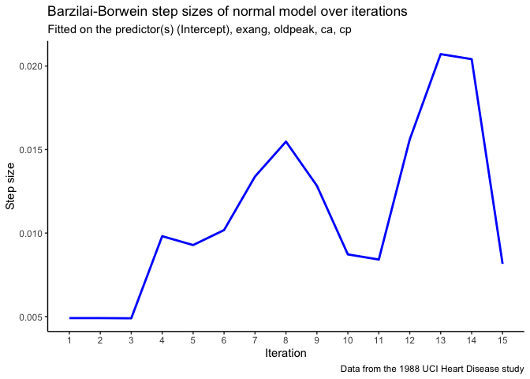

```r
plot_steps(model = log_model, model_type = "normal")
```

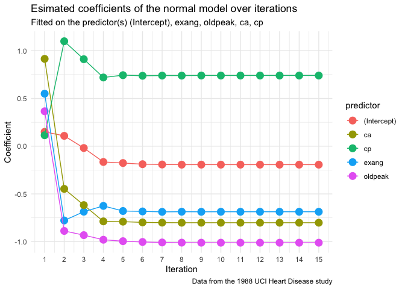

```r
plot_betas(model = log_model, model_type = "normal")
```

Another way that we can visualize our model’s versus R’s `glm` model’s coefficients is by layering them over iterations like shown in the plot below. We use a custom method called `coefficients_comparison`.

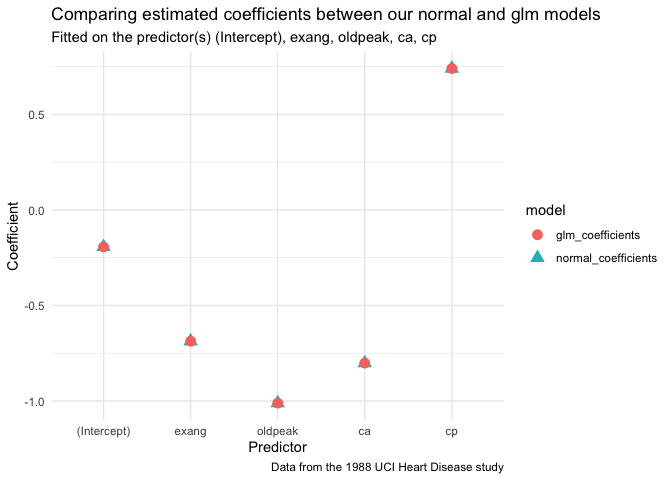

```r
coefficients_comparison <- function(model, r_model) {
    final_coefficients <- model$coefficients[nrow(model$coefficients),]
    r_coefficients <- r_model$coefficients

    predictors <- model$predictors

    to_plot <- data.frame(
        predictor = factor(predictors, levels=predictors),
        normal_coefficients = final_coefficients,
        glm_coefficients = r_coefficients
    ) %>% pivot_longer(
        cols = -predictor,
        names_to = "model",
        values_to = "coefficient"
    )

    ggplot(to_plot, aes(x = predictor, y = coefficient, shape = model, color = model)) +
        geom_point(size = 3, stroke = 1.2) +
        labs(x = "Predictor", y = "Coefficient") +
        labs(title = "Comparing estimated coefficients between our normal and glm models",
                 subtitle = paste("Fitted on the predictor(s)", toString(predictors)),
                 caption = "Data from the 1988 UCI Heart Disease study") +
        theme_minimal()
}

coefficients_comparison(model = log_model, r_model = r_model)
```

From the above plot we see that our normal model and R’s `glm` model have essentially the same coefficients which matches the comparison table seen earlier. We can now analyze the prediction metrics of our model and R’s `glm` model to evaluate their effectiveness as well as compare to our naive model.

```r
log_metrics <- prediction_metrics(
    model = log_model,
    training = training,
    testing = testing,
    model_type = "normal",
    is_glm = FALSE
)
r_metrics <- prediction_metrics(
    model = r_model,
    training = training,
    testing = testing,
    model_type = "glm",
    is_glm = TRUE
)
```

We now look at the accuracy and area under curve (AUC) metrics across all three models as summarized in the following table.

```r
all_metrics <- data.frame(
    "training accuracy" = c(
        naive_metrics$training_accuracy,
        log_metrics$training_accuracy,
        r_metrics$training_accuracy
    ),
    "training auc" = c(
        naive_metrics$training_auc,
        log_metrics$training_auc,
        r_metrics$training_auc
    ),
    "testing accuracy" = c(
        naive_metrics$testing_accuracy,
        log_metrics$testing_accuracy,
        r_metrics$testing_accuracy
    ),
    "testing auc" = c(
        naive_metrics$testing_auc,
        log_metrics$testing_auc,
        r_metrics$testing_auc
    )
)

rownames(all_metrics) <- c("naive model", "normal model", "glm model")
colnames(all_metrics) <- c("training accuracy", "training auc", "testing accuracy", "testing auc")

all_metrics
```

```
##              training accuracy training auc testing accuracy testing auc
## naive model              53.75        52.68            54.60       52.40
## normal model             79.64        79.62            80.52       80.55
## glm model                79.64        79.62            80.52       80.55
```

In all metrics, our adjusted model outperforms the naive model and is on par with the glm. A high AUC indicates that the accuracy of our model is such that we face a favourable trade-off between false and true positives through adjusting a classification threshold. This is something we analyse more strongly in the more strongly predictive models later.

To grasp this visually, we want to also view the Receiver Operating Characteristic (ROC) curve available via the `pROC` library in our wrapper function of `plot_ROC` to compare the true and false positive rates. Note that this is plotted on the `testing` data as another visualization of model accuracy. As expected, the naive model is slightly over 50% which indicates that our gradient descent implementation picks up some slight noise in the data but is overall not much better than flipping a coin to determine heart disease presence based on `exang`, `oldpeak`, and `ca`.

Alternatively, our model and R’s `glm` model both have an AUC of 81% which suggests that they perform strongly in distinguishing between CAD presence and absence.

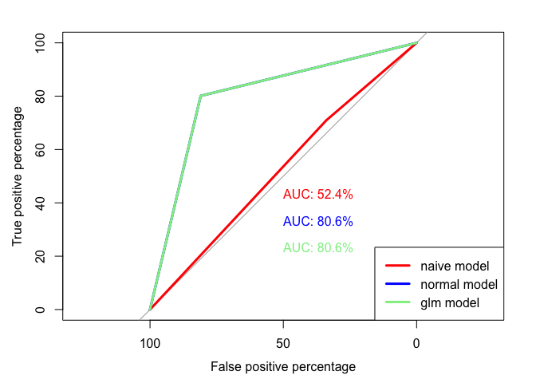

```r
plot_ROC <- function(metrics, curve_color, y_height, add_to = FALSE) {
    # `y_height` is the height where the AUC percentage label is printed so that they do not
    # overlap; `add_to` is needed to overlap the naive, normal, and glm model ROC curves
    roc_object <- roc(
        response = metrics$true_classes_testing,
        predictor = metrics$prediction_classes_testing,
        plot = TRUE,
        percent = TRUE,
        xlab = "False positive percentage",
        ylab = "True positive percentage",
        col = curve_color,
        lwd = 3,
        print.auc = TRUE,
        print.auc.y = y_height,
        add = add_to,
        quiet = TRUE
    )
}

plot_ROC(metrics = naive_metrics, curve_color = "red", y_height = 45, add_to = FALSE)
plot_ROC(metrics = log_metrics, curve_color = "blue", y_height = 35, add_to = TRUE)
plot_ROC(metrics = r_metrics, curve_color = "lightgreen", y_height = 25, add_to = TRUE)

models <- c("naive model", "normal model", "glm model")
colors <- c("red", "blue", "lightgreen")

legend("bottomright", legend = models, col = colors, lwd = 3)
```

The above ROC plot is useful to see visually how the models compare but we would like to see hard values for the true and false positives and negatives across the testing subset for our model. This is done through the confusion matrix shown below.

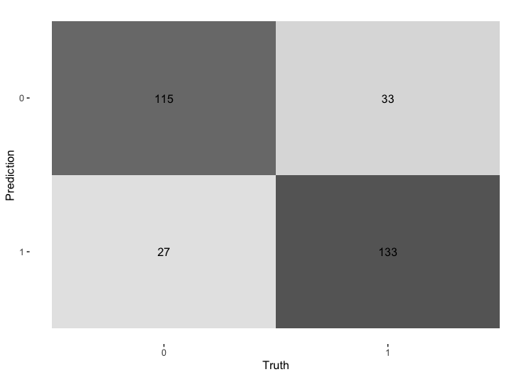

```r
testing_df <- data.frame(
    y = as.factor(testing$target),
    y_hat = as.factor(log_metrics$prediction_classes_testing)
)
confusion_matrix <- testing_df %>%
    conf_mat(truth = y, estimate = y_hat) %>%
    autoplot(type = "heatmap") %>%
    print
```

## Non-baseline Interpretable Model: Short Depth Classification Tree

### Motivation

We choose a **short classification tree** as a relatively interpretable model, given that it can be read and understood in an intuitive way without necessarily having specific domain knowledge.

This is because instead of using a complicated functional form for how the outcome depends on its predictors, when a tree is fit to data, at each level of depth it creates a single split into different groupings, or “nodes.” For example, all those patients with `cp` (chest pain type) above 0.5 (on a scale of 0 through 3 inclusive, with 3 being the most severe chest pain) may be assigned to one grouping and those below to another group. This divergence/splitting by construction means each grouping will have different characteristics (which are used to predict probabilities). In turn, at each consequent level of depth, these groupings are split further and further based on being either side of a threshold for a chosen predictor.

Each of these splits is created in such a way to maximise node purity. This is done by assigning the predicted probability of the positive class conditional on being in that node (and having predictor values that put a patient in that grouping) as the proportion of training observations in the positive class.

It then seeks to achieve maximum node purity by minimising the Gini Index, which takes its smallest values (closest to 0) if either all the predicted probabilities are close to 1, or all of them are close to 0 (James, Witten, Hastie, & Tibshirani, 2023). Intuitively, it can be seen that when a grouping is more “pure” (i.e., the observations tend to have more similar outcomes), then it makes more sense for a tree to define a split that creates such a grouping, and consequently associate the characteristics that put a patient into that group as characteristics associated with the probability of the positive class in that group.

This ultimately creates discrete, mutually exclusive and collectively exhaustive final groupings/nodes, each of which have certain characteristics.

This recursive splitting process directly maps to flow diagram process for iteratively distinguishing and grouping patients. Therefore, it can be crucially informative for diagnosis.

A medical professional can proceed by gathering key data on a patient, and iteratively going through a checklist.

At the first bullet or “depth” level of the checklist, a piece of information on the patient is used to put them into a sub group, depending on whether they exceed or fall short of a given threshold on that data point.

At each subsequent “depth” level in the checklist, another piece of information on the patient (perhaps one already used before) is used to put them into a sub group of the group they were just in. Eventually, the patient is placed in one of the final groupings.

Based on this grouping, and the charactestics associated with being in that grouping, the medical professional can predict the chance (conditional on those characteristics) that that patient will have heart disease. If this probability is sufficiently high, a positive diagnosis can be given.

In the case of heart disease diagnosis, we might not simply want the highest accuracy, but perhaps particularly avoid false negatives (and maximise true positives, even at the cost of false positives). This depends, of course, on the treatments prescribed to the patient.

**Treatments often fall into one of the below groupings:** [Sourced from (British Heart Foundation, 2025) (NHS, 2025) (Mayo Clinic, 2025)]

1. **Lifestyle changes**
- Exercise (strengthen your heart muscles and widen blood vessels)
- Healthy Eating (target the root cause)
- Ceasing to smoke (improve your body’s functioning)
2. **Medicines**
- Blood Thinners (to prevent blood clotting and blocking blood vessels)
- Statins (to lower cholesterol)
- Beta Blockers (to slow heartbeat and improve blood flow using hormones)
- Nitrates (to widen blood vessels)
- ACE Inhibitors or ARBs (reduce a hormone that would cause blood vessels to narrow)
- Calcium Chanel Blockers (relax muscles on the walls of arteries, making them wider)
3. **Surgical procedures** (usually only implemented with a check on a coronary angiogram)
- Coronary angioplasty (small balloon inflated to push fatty tissue of a narrowed blood vessel outwards, improving blood flow)
- Bypass surgery (CABG) (a new blood vessel is inserted to bypass a blocked section of an existing vessel)
- Heart transplant (replace the patient’s dysfunctional heart with one that works better)

On the one hand, false positives may cause undue stress, when someone is misleadingly worried about heart disease that they may not have.

If prescribed treatment is benign, such as in the case of lifestyle changes, it will make sense to be less cautious about coming to a positive diagnosis because taking on this prescription will at best come at large personal benefits and at worst incur marginal costs relative to those benefits. Eating less sugar and saturated fat leads to a slight quality of life reduction in the short term, but a healthier lifestyle has substantial benefits and often improves quality of life in the long term and that derived from profound and not superficial pleasures, even if a patient does not yet have nor is at risk of heart disease.

This applies also to more mild medicine prescriptions, with side-effects extending from negligible symptoms to some only as severe as dizziness, headaches and fatigue (ibid).

However, to the extent that treatments are more severe in their nature, such as stronger medicines or surgical procedures, we may wish to use a higher threshold to avoid the consequences of prescribing treatment to someone who was not at risk. Moving forward, due to the fact that variables in our data has not been previously used to prescribe surgical treatment, and the binary nature of our outcome variable has no indication of the severity of heart disease, which would be essential in this application, we will only consider the applications for diagnosis that results in lifestyle change and medicine prescriptions.

Likewise, any non-professional (perhaps a patient themselves, or a trainee) could also use such a flow chart structure to identify the chance of a positive diagnosis/ what factors tend to be most associated with high risk of heart disease, making it more practical to diagnose on a larger scale.

This first tree flow chart can be used either for informative purposes as to what may tentatively be leading factors behind heart disease, or diagnosis situations in which all the measures in the training data are accessible to the professional giving the diagnosis.

In this case, we use the `rpart` engine as opposed to the `tree` engine for more pleasant visualisations.

#### Pre-Adjustment

We will eliminate the target and sex factor column, since we no-longer need it. Target in this section is classed as y.

```r
Heart_train_old <- Heart_train # save out the old data in case we need it
Heart_train <- Heart_train %>% dplyr::select(-target , -sex_factor) #eliminate the unneeded columns
Heart_train_new <- Heart_train # save the new data to return to it later
```

### Model With All the Predictors

#### Validate the Best Tuning Parameters

We begin by setting up a tuning grid and then viewing its validation set accuracy, plotting this accuracy against a tuning parameter and gauging which level of complexity appears to achieve the best simplicity-accuracy trade-off.

```r
tuning_grid_tree <- expand.grid(
    cp = c(0.001),
    maxdepth = c(1,3,4,5,6,8,10,15,20),  # Limit tree depth
    min_n = c(5),  # Number of obs per split, so if higher, reduces splits
    thresh = c(0.3,0.4, 0.5),
    formula = as.character("y ~.")
)

tuning_grid_tree$formula <- as.character(tuning_grid_tree$formula)

tree_output <- grid_validate_tidy(Heart_train, Heart_valid, tuning_grid_tree, "tree", "rpart")
```

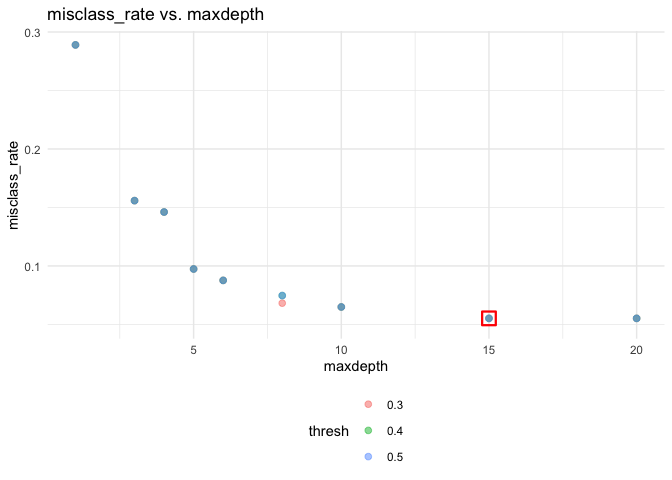

```r
plot_grid(tree_output$accuracy_df, val_measure = "misclass_rate", tp1 = "maxdepth", tp2 = "thresh")
```

It is observable that once we reach depth 4, the validation set accuracy is relatively high, with only an approximate and acceptable 15% misclassification rate. Nonetheless, the short depth retains interpretability.

We then move on to analyze our results by extracting and observing the tuning parameters of the chosen specification. After we look at the confusion matrix of this chosen specification and then its ROC curve to gauge its cut-off trade-off.

```r
# Check the predictions of the model with the best trade-off:
best_spec_idx <- 3 # since this is still relatively interpretable.
tree_fit_predictions <- tree_output$preds %>%
  filter(spec_no == best_spec_idx)
tree_fit <- tree_output$model_fits[[best_spec_idx]]
#tree_output$accuracy_df[ best_spec_idx, ]
```

```
## Rows: 1
## Columns: 6
## $ misclass_rate <dbl> 0.1461039
## $ cp            <dbl> 0.001
## $ maxdepth      <dbl> 4
## $ min_n         <dbl> 5
## $ thresh        <dbl> 0.3
## $ formula       <chr> "y ~."
```

#### Check the Accuracy of the Best Model

##### Using A Confusion Matrix

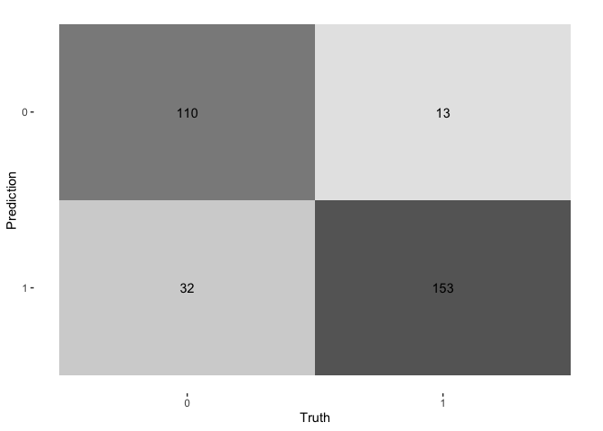

```
## [1] "misclass_rate : 0.146103896103896"
```

```r
graph_preds(tree_fit_predictions$preds, tree_fit_predictions$y, cm=T, scatter=F)
```

##### Using an ROC Curve

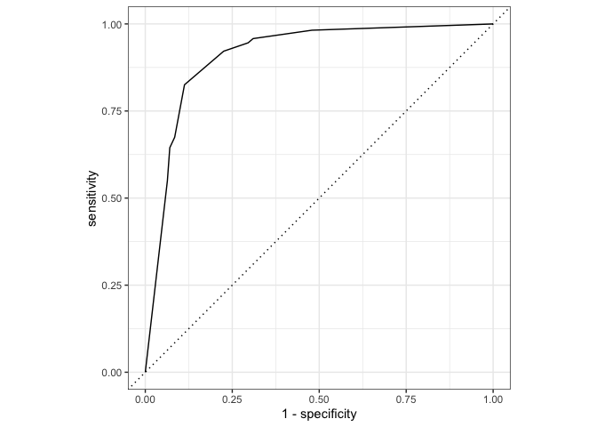

```r
tree_fit_predictions %>%
    roc_curve(truth = y, prob_preds, event_level = "second")  %>%
    autoplot()
```

Note that the classification tree only requires that our false positive rate exceeds aprrox. 15% if we should wish to have higher than 75% classification accuracy, lower than the logit. This means that the predictive accuracy (at least within distribution) of a tree model is such that we face a **more favourable tradeoff** with diagnosing patients.

#### Analyse the Checklist

We now use the best tree model to learn about our data by using the `rpart` engine.

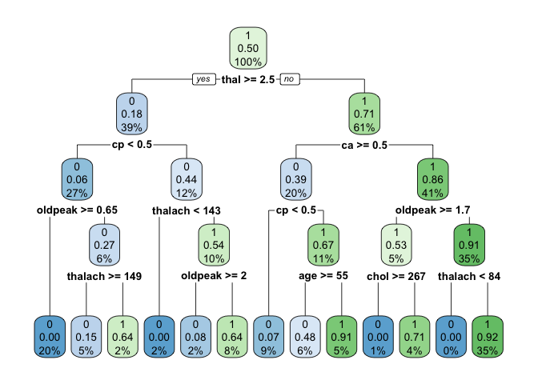

```r
# Define the best model specification
best_model_spec <- decision_tree(
    mode = "classification",
    cost_complexity = best_params$cp,  # Cost-complexity pruning
  tree_depth = best_params$maxdepth,  # Max depth of tree
  min_n = best_params$min_n  # Minimum number of observations per node
) %>%
  set_engine("rpart")

# Create workflow
best_workflow <- workflow() %>%
  add_model(best_model_spec) %>%
  add_formula(as.formula(best_params$formula))

# Fit the model to full training data
best_tree_fit <- fit(best_workflow, data = Heart_train)

# Extract the fitted model
best_rpart_model <- extract_fit_engine(best_tree_fit)  # Gets the rpart model

# Plot the tree
rpart.plot(best_rpart_model, roundint = FALSE)
```

```r
# the roundint = false is used to avoid a warning that rpart Cannot retrieve the original training data used to build the model (so cannot determine roundint and is.binary for the variables)
```

### Limiting to Only Practical Measurements

By asking *How would [our tree] change with access to limited predictors?* we filter our input space for the most measurable medical characteristics to fit on later.

```r
# We now only select a SUBSET of Heart_train which includes only the most practically measurable data
Heart_subset <- Heart_train %>% select(y, sex, age, chol, trestbps)
```

#### Validate the Best Tuning Parameters

We now look for a depth level that has high levels of prediction accuracy yet not uninterpretable (would not result in a very long checklist).

```r
tuning_grid_tree <- expand.grid(
  cp = c(0.001),
  maxdepth = c(1,3,4,5,6,8,10,15,20),  # Limit tree depth
  min_n = c(5),  # Number of obs per split, so if higher, reduces splits
  thresh = c(0.3,0.4, 0.5),
  formula = as.character("y ~.")
)

tuning_grid_tree$formula <- as.character(tuning_grid_tree$formula)
```

We do a similar analysis as above by graphing the prediction accuracy for each tuning parameter level.

```r
tree_output <- grid_validate_tidy(Heart_subset, Heart_valid, tuning_grid_tree, "tree", "rpart")
```

```
##    misclass_rate    cp maxdepth min_n thresh formula
## 1     0.46103896 0.001        1     5    0.3    y ~.
## 2     0.33766234 0.001        3     5    0.3    y ~.
## 3     0.31168831 0.001        4     5    0.3    y ~.
## 4     0.29870130 0.001        5     5    0.3    y ~.
## 5     0.25324675 0.001        6     5    0.3    y ~.
## 6     0.20129870 0.001        8     5    0.3    y ~.
## 7     0.15584416 0.001       10     5    0.3    y ~.
## 8     0.09415584 0.001       15     5    0.3    y ~.
## 9     0.09415584 0.001       20     5    0.3    y ~.
## 10    0.37662338 0.001        1     5    0.4    y ~.
## 11    0.34090909 0.001        3     5    0.4    y ~.
## 12    0.30844156 0.001        4     5    0.4    y ~.
## 13    0.30194805 0.001        5     5    0.4    y ~.
## 14    0.25324675 0.001        6     5    0.4    y ~.
## 15    0.20454545 0.001        8     5    0.4    y ~.
## 16    0.15259740 0.001       10     5    0.4    y ~.
## 17    0.10064935 0.001       15     5    0.4    y ~.
## 18    0.10064935 0.001       20     5    0.4    y ~.
## 19    0.37662338 0.001        1     5    0.5    y ~.
## 20    0.37012987 0.001        3     5    0.5    y ~.
## 21    0.30844156 0.001        4     5    0.5    y ~.
## 22    0.30194805 0.001        5     5    0.5    y ~.
## 23    0.24025974 0.001        6     5    0.5    y ~.
## 24    0.20454545 0.001        8     5    0.5    y ~.
## 25    0.15259740 0.001       10     5    0.5    y ~.
## 26    0.10064935 0.001       15     5    0.5    y ~.
## 27    0.10064935 0.001       20     5    0.5    y ~.
```

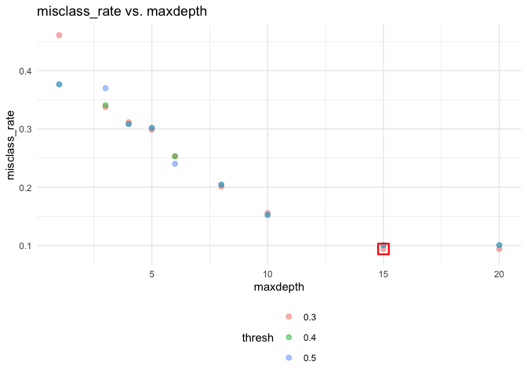

```r
plot_grid(tree_output$accuracy_df, val_measure = "misclass_rate", tp1 = "maxdepth", tp2 = "thresh")
```

Instead, a depth 8 tree works quite well. Although this is an 8-point checklist, it is still not that many points and requires fewer readings to be taken than the earlier model which allowed predictions to be made on all 13 measures at our disposal. We can show this by comparing a depth 4 tree to a depth 8 tree.

We run the above procedure on a depth 4 tree.

```r
# Check the predictions of the model with the best trade-off:
best_spec_idx <- 21 # since this is still relatively interpretable.
tree_fit_predictions <- tree_output$preds %>%
  filter(spec_no == best_spec_idx)
tree_fit <- tree_output$model_fits[[best_spec_idx]]
#tree_output$accuracy_df[ best_spec_idx, ]
```

```
## Rows: 1
## Columns: 6
## $ misclass_rate <dbl> 0.3084416
## $ cp            <dbl> 0.001
## $ maxdepth      <dbl> 4
## $ min_n         <dbl> 5
## $ thresh        <dbl> 0.5
## $ formula       <chr> "y ~."
```

#### Check the Accuracy of the Best Model

##### Using A Confusion Matrix

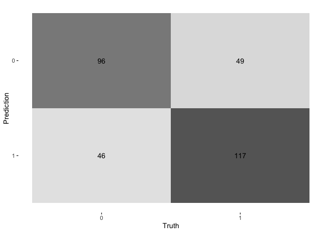

```
## [1] "misclass_rate : 0.308441558441558"
```

```r
graph_preds(tree_fit_predictions$preds, tree_fit_predictions$y, cm=T, scatter=F)
```

##### Using an ROC Curve

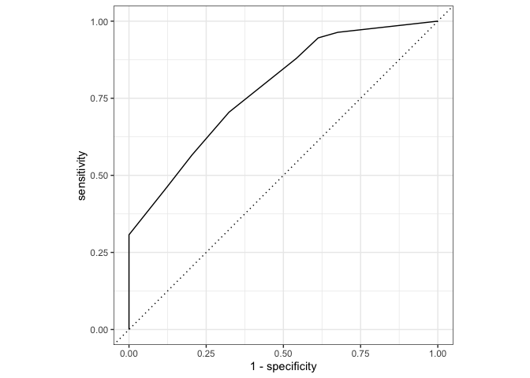

```r
tree_fit_predictions %>%
    roc_curve(truth = y, prob_preds, event_level = "second") %>%
  autoplot()
```

Because we have access only to limited measurements, we would need to trade-off more than 25% in false postive diagnoses to achieve higher than 75% accuracy, which is worse even than the logit model.

However, this is if we are limiting ourselves to a depth 4 (or 4-step) diagnosis process. If we increased this to 8, which is still retalively managable, we find the following.

```r
# Check the predictions of the model with the best trade-off:
best_spec_idx <- 6 # since this is still relatively interpretable.
tree_fit_predictions <- tree_output$preds %>%
  filter(spec_no == best_spec_idx)
tree_fit <- tree_output$model_fits[[best_spec_idx]]
#tree_output$accuracy_df[ best_spec_idx, ]
```

```
## Rows: 1
## Columns: 6
## $ misclass_rate <dbl> 0.2012987
## $ cp            <dbl> 0.001
## $ maxdepth      <dbl> 8
## $ min_n         <dbl> 5
## $ thresh        <dbl> 0.3
## $ formula       <chr> "y ~."
```

#### Check the Accuracy of the Best Model

##### Using A Confusion Matrix

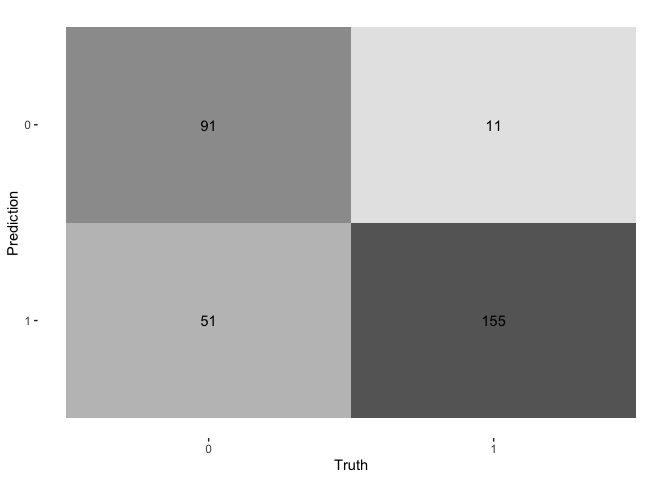

```
## [1] "misclass_rate : 0.201298701298701"
```

```r
graph_preds(tree_fit_predictions$preds, tree_fit_predictions$y, cm=T, scatter=F)
```

##### Using an ROC Curve

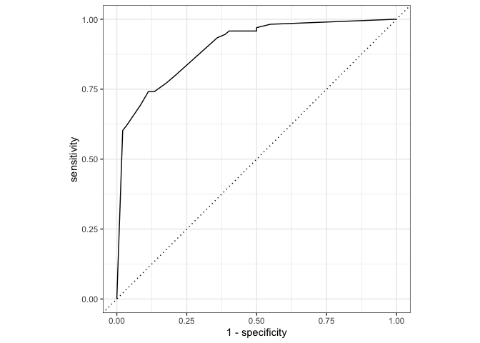

```r
tree_fit_predictions %>%
  roc_curve(truth = y, prob_preds, event_level = "second") %>%
  autoplot()
```

## Causality and Suggestive Treatment

### Directed Acyclic Graph (DAG)

To support the interpretation of the decision tree and identify possible sources of confounding, we used a DAG to visualise the causality between variables.

Causality in heart disease can be understood via a DAG which maps the relationships between various contributing predictors. In our DAG, we focus on six variables that we believe most significantly influence the likelihood of developing heart disease.

Ranked in order of relative impact, the most influential predictor is `oldpeak`, which measures ST depression on an electrocardiogram (Patil, 2025). This reflects how the heart responds under stress compared to rest, with a downward slope indicating potential dysfunction (Patil, 2025). Next is `ca`, which captures the number of major blood vessels showing signs of blockage (Patil, 2025). The more vessels affected, the higher the cardiovascular risk (Patil, 2025). `Trestbps`, recording resting blood pressure, follows closely, as high blood pressure at rest is linked to heart disease, stroke and chronic cardiovascular issues (Patil, 2025).

The fourth predictor is `restecg`, which looks at resting electrocardiogram results (Patil, 2025). Abnormalities here may potentially signal increased strain on the heart or underlying valvular defects (Patil, 2025). The last two predictors, `chol` (cholesterol levels) and `fbs` (fasting blood sugar) are generally considered more manageable through lifestyle changes (Patil, 2025). Diet, exercise and medication can significantly reduce their impact, whereas the other variables often indicate deeper physiological issues that may require surgical intervention (Patil, 2025).

These predictors not only contribute individually but are also interlinked. For instance, higher fasting blood sugar can lower HDL (good cholesterol) and raise LDL (bad cholesterol) worsening lipid profiles (Patil, 2025). Greater cholesterol levels lead to plaque build-up in the arteries, narrowing them and forcing the heart to work harder (Patil, 2025). This can result in increased blood pressure, known as hypertension, which is often detected as ST depression on an ECG (Patil, 2025). Such findings might prompt further investigation through procedures like a fluoroscopy to assess the extent of cardiovascular damage (Patil, 2025).

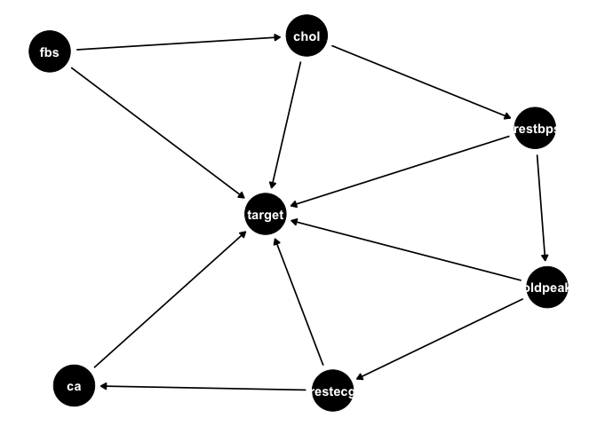

```r
# DAG
heart_dag <- ggdag::dagify(chol ~ fbs,
                           trestbps ~ chol,
                           oldpeak ~ trestbps,
                           restecg ~ oldpeak,
                           ca ~ restecg,
                           target ~ fbs,
                           target ~ chol,
                           target ~ trestbps,
                           target ~ oldpeak,
                           target ~ restecg,
                           target ~ ca)

ggdag::ggdag(heart_dag) + theme_void()
```

### Confounding

To explore the role of confounding, we decided to look at GLMs guided by our DAG structure.

Please note that while the coefficients discussed remain valid in terms of magnitude and relative importance, their directional interpretation should be considered in reverse, for the reasons discussed at the beginning of our report.

If we were to include only `trestbps` (resting blood pressure) as a predictor in a logistic regression model against the target, the estimated effect on the log-odds of heart disease might appear stronger than it actually is. This overestimation occurs because `trestbps` is positively correlated with cholesterol, a variable omitted in this simplified model. When blood pressure rises, it coincides with an underlying increase in cholesterol levels. As a result, the model mistakenly attributes some of cholesterol’s influence on target to `trestbps`, leading to a higher coefficient. This is an example of Omitted Variable Bias, where the absence of a relevant predictor, in our case cholestrol, causes the effect of an included variable to be biased in magnitude.

```r
glm2 <- glm(y ~ trestbps, data = Heart_train, family = binomial)
summary(glm2)
```

```
##
## Call:
## glm(formula = y ~ trestbps, family = binomial, data = Heart_train)
##
## Coefficients:
##              Estimate Std. Error z value Pr(>|z|)
## (Intercept)  2.208806   0.580890   3.802 0.000143 ***
## trestbps    -0.016724   0.004383  -3.816 0.000136 ***
## ---
## Signif. codes:  0 '***' 0.001 '**' 0.01 '*' 0.05 '.' 0.1 ' ' 1
##
## (Dispersion parameter for binomial family taken to be 1)
##
##     Null deviance: 993.96  on 716  degrees of freedom
## Residual deviance: 978.80  on 715  degrees of freedom
## AIC: 982.8
##
## Number of Fisher Scoring iterations: 4
```

Therefore, we add both `fbs` and `chol` as controls. All predictors are standardised via the scale function to help simplify interpretations.

```r
# scale predictors
trestbps_scale <- scale(Heart_train$trestbps)
chol_scale <- scale(Heart_train$chol)
fbs_scale <- scale(Heart_train$fbs)

#fit the model again
glm3 <- glm(y ~ trestbps_scale + chol_scale + fbs_scale, data = Heart_train, family = binomial)
summary(glm3)
```

```
##
## Call:
## glm(formula = y ~ trestbps_scale + chol_scale + fbs_scale, family = binomial,
##     data = Heart_train)
##
## Coefficients:
##                 Estimate Std. Error z value Pr(>|z|)
## (Intercept)     0.006744   0.075740   0.089 0.929046
## trestbps_scale -0.270401   0.079852  -3.386 0.000709 ***
## chol_scale     -0.164106   0.077564  -2.116 0.034366 *
## fbs_scale      -0.023906   0.076971  -0.311 0.756116
## ---
## Signif. codes:  0 '***' 0.001 '**' 0.01 '*' 0.05 '.' 0.1 ' ' 1
##
## (Dispersion parameter for binomial family taken to be 1)
##
##     Null deviance: 993.96  on 716  degrees of freedom
## Residual deviance: 974.11  on 713  degrees of freedom
## AIC: 982.11
##
## Number of Fisher Scoring iterations: 4
```

## High-Dimensional Model: Ordinal Logistic Regression with Lasso Regularisation

Lasso regression is utilised to ensure that the most important predictors are selected, again, consistent with our objectives of practicality in diagnosis.

Lasso regression is a regression method that introduces an L1 penalty on the coefficients of the predictors. The L1 penalty ensures sparsity in the model by shrinking coefficients of less important predictors to zero, performing feature selection.

Note that, as mentioned earlier, multicollinearity limits the appropriateness of this form of regularisation over the ridge, but the ridge method does not lead to a reduction in the number of predictors deemed to be relevant, simply a gradual shrinking in their coefficients. Our aim here is for sparsity.

$$\ell_{\text{Lasso}}(\beta) = -\sum_{i=1}^{n} \left[ y_i \log(p(x_i)) +
(1 - y_i) \log(1 - p(x_i)) \right] + \lambda \sum_{j=1}^{p} |\beta_j|$$

such that

$$-\sum_{i=1}^{n} \left[ y_i \log(p(x_i))
+ (1 - y_i) \log(1 - p(x_i)) \right]$$

is the logistic loss for binary classification with $p(x_i) = \frac{1}{1 + e^{-x_i \beta}}$ being the logistic function, $\lambda$ is the parameter controlling the strength of the L1 penalty and $\sum_{j=1}^{p} |\beta_j|$ is the L1 penalty term which ensures sparsity in the coefficients

The optimal value of $\lambda$ is determined using $k$-fold cross-validation, namely a 10-fold approach. The selected predictors are those with non-zero coefficients in the Lasso model:

$$\text{selected_predictors} = \{X_i \mid \beta_i \neq 0\}$$

### Pre-Processing

Beforehand, we need to return to the dataset with the target variable column

```r
Heart_train <- Heart_train_old
```

### Fit the Lasso Logit Regression

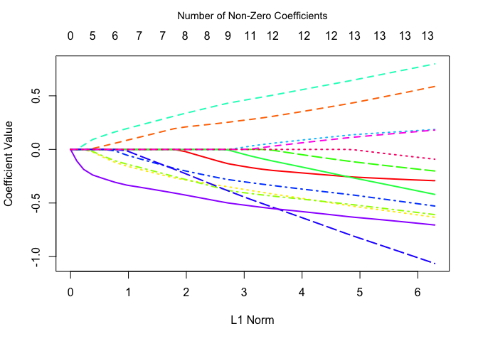

```
## numeric(0)
```

```r
Heart_train$target_numeric <- as.numeric(Heart_train$y) - 1

x <- scale(model.matrix(target_numeric ~ age + thalach + ca + oldpeak + trestbps + chol + cp + slope + thal + sex_factor + exang + restecg + fbs, data = Heart_train))[, -1]
y <- Heart_train$target_numeric

train <- sample(1:nrow(x), nrow(x) / 2) # train test split
test <- setdiff(1:nrow(x), train)
y.test <- y[test]

grid <- 10^seq(0, -10, length = 200) # decreasing lambda grid

lasso_model <- glmnet(x[train, ], y[train], alpha = 1, lambda = grid, family = "binomial")

beta <- as.matrix(lasso_model$beta)
l1_norm <- colSums(abs(beta))  # calculating l1_norm

# duplicate L1 norms removed
unique_idx <- !duplicated(round(l1_norm, 5))
l1_norm_unique <- l1_norm[unique_idx]
beta_unique <- beta[, unique_idx]
n_nonzero <- colSums(beta_unique != 0)


matplot(l1_norm_unique, t(beta_unique), type = "l" , lwd = 2,
        xlab = "L1 Norm", ylab = "Coefficient Value",
        col = rainbow(nrow(beta_unique)), xlim = range(l1_norm_unique))  + axis(3, at = l1_norm_unique, labels = n_nonzero, line = 0, tick = FALSE) + mtext("Number of Non-Zero Coefficients", side = 3, line = 2.5, cex = 0.9) # manual L1 norm plot
```

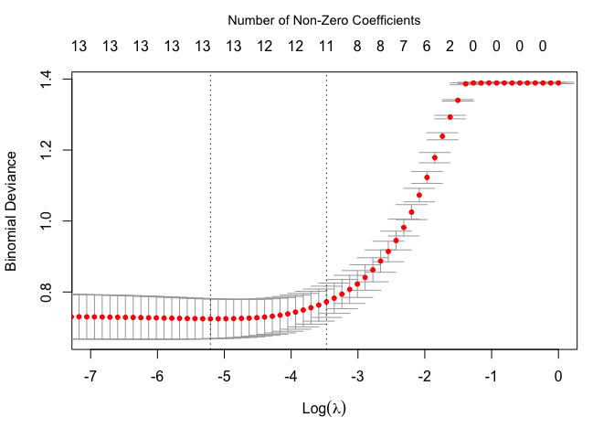

```
## integer(0)
```

```r
lasso_model_cv <- cv.glmnet(x[train, ], y[train], alpha = 1, lambda = grid, family = "binomial", nfolds = 10) # lasso cross validated
plot(lasso_model_cv, xlim = c(-7, 0)) + mtext("Number of Non-Zero Coefficients", side = 3, line = 2.5, cex = 0.9, font = 1)
```

```r
best_lambda <- lasso_model_cv$lambda.min
best_lambda
```

```
## [1] 0.005478901
```

```r
out <- glmnet(x, y, alpha = 1, lambda = grid, family = "binomial") #glmnet refitted on all data

lasso.coef <- predict(out, type = "coefficients", s = best_lambda) # coefficients extracted from out

selected_predictors <- rownames(lasso.coef)[lasso.coef[, 1] != 0][-1] # checking if predictors exist in dataset
selected_predictors <- intersect(selected_predictors, colnames(Heart_train))
selected_predictors # predictors ranked before the for loop
```

```
##  [1] "age"      "thalach"  "ca"       "oldpeak"  "trestbps" "chol"
##  [7] "cp"       "slope"    "thal"     "exang"    "restecg"
```

```r
predictor_pairs <- combn(selected_predictors, 2, simplify = FALSE) # all predictor combinations are generated

results <- data.frame(Predictor1 = character(),
                      Predictor2 = character(),
                      MisclassificationRate = numeric()) # predictor combos stored
```

[output not shown]

## Predictively Accurate Model Without Interpretability: Classification Random Forest

Earlier, we evaluated how a single tree model could result in a more-desirable trade-off of more false positive diagnoses in return for more true positive diagnoses compared to a logit, but **only** if either we had access to measurements that are less practical to gather from a patient, **or** we were willing to extend the depth and complexity of the tree, and hence, the time it would take for a medical professional to carry out a step-based “checklist” diagnostic process.

However, in many environments today (including even in emerging economies or in the field), medical professionals have access to computer hardware and software that may be sufficient to run predictive models on new patient data to predict conditional probabilities for patients. This eliminates the need for a step-based “checklist” process, and allows diagnoses to be made systematically fora large number of patients in one go.

Of course, medical professionals still have to gather the data from patients, which means that we should still give priority to models that support the practicality of this part of the process. In other words, we will place priority on model specifications which use:

- Fewer measures (that thus take less time to collect)
- Measures that are more practical to collect on the spot.

It therefore makes sense to consider models that may be more complex and less interpretable, but offer benefits to predictive accuracy (with a desireable trade-off) and practicality that make them more applicable for diagnosis (although perhaps not as interpretable for prescribing treatment).

For this, we choose to use a **random forest** model, which has a few predictive advantages:

- **Low bias**, because it uses the predictions of numerous trees that are grown deep and so can fit the complex patterns in the data more closely.
- **Low variance**, because it averages out the predictions of a large number of trees, each fitted on a bootstrapped (i.e., sampled with replacement) subsample of the training dataset.
- **Low variance**, because (unlike **bagging**, a special case of **random forests**) it allows splits only on a certain subset of predictors, meaning that each tree is less correlated with the next, and so is less likely to amplify overfitting to our data.

These combine to create a model that has **high predictive accuracy** on **new** data, and, ideally, not just on new data from our our same wider dataset (i.e., can be used to generalise in the distribution), but also from new datasets (which may be out of distribution, to the extent that the underlying relationships have changed).

In other words, such a fitting procedure should capture as accurately the **fundamental** or **structural** relationships between the variables that do not change throughout time, as opposed to the **transitory** or **reduced form** relationships.This means that the **low bias** feature of our flexible model fitting procedure is particularly useful for this out of distribution generalisation.

Using a validation set approach, we can only guarantee the former, that we can generalise well within distribution. We aim to avoid too much “optimism” (encouraging our empirical risk to consistently underestimate the true risk), by avoiding the use of excessive degrees of freedom, yet also using sufficient predictors to reduce the irreducible error (we want it to be the case that a true function *of these predictors* is as good at predicting heart disease as possible).

We do this by choosing the tuning parameters and model specification to maximise validation (and not training) set accuracy. In other words, we attempt to ensure we capture the underlying relationships *in our wider data* as much as possible without just falsely misinterpreting the random noise or intricacies of the training subset *of our data* as signals of the underlying relationship.

As for the latter, we argue that the fact that the human body works much in the same way today than it did many decades ago (NHS, 2025) (National Institutes of Health, 2025) means that much of the relationships we capture hold true throughout time. Although the distribution and data generating process today has some differences to the time when the data was gathered, it is still similar to the distribution of our dataset, given that the structural biological relationships still hold.

However, the distribution and data generating process for a population in a different geographical area with therefore a different corresponding hereditary background is more likely to be fundamentally different to the narrow population in our dataset at any given point in time, because hereditary (gene-related) characteristics will are more likely to affect the relationships and more significantly and systematically so (British Heart Foundation, 2025). To the extent that these differences have a minor aggregate effect, the distributions of our data and this outside sample are still similar.

In particular, we argue that between our Cleveland sample and the wider US, we may introduce more variation in hereditary factors that slightly alter the idiosyncratic relationships, and thus increase irreducible error (our model does not account for these factors, so will simply mis-estimate a little more). However, these will not be *systematically* different to those in our Cleveland sample, so will mean that our estimate of the data generating process is not *systematically wrong* or biased.

We first create a tuning grid and for the random forest and then view the grid as well as its plot before analyzing the results.

### Pre-Adjustment

We need to re-use the heart_train_new dataset without the columns that are not necessary for this section.

```r
Heart_train <- Heart_train_new
```

### Validate Best Tuning Parameters

#### Set up a Grid of Tuning Parameters

```r
tuning_grid_rf <- expand.grid(
  mtry = 1:6,
  trees = c(500),
  thresh = c(0.4, 0.5),
  formula = as.character(formulas[3])
)
tuning_grid_rf$formula = as.character(tuning_grid_rf$formula)
```

```
##    mtry trees thresh
## 1     1   500    0.4
## 2     2   500    0.4
## 3     3   500    0.4
## 4     4   500    0.4
## 5     5   500    0.4
## 6     6   500    0.4
## 7     1   500    0.5
## 8     2   500    0.5
## 9     3   500    0.5
## 10    4   500    0.5
## 11    5   500    0.5
## 12    6   500    0.5
##                                                           formula
## 1  y ~ age + sex + cp + trestbps + chol + fbs + restecg + thalach
## 2  y ~ age + sex + cp + trestbps + chol + fbs + restecg + thalach
## 3  y ~ age + sex + cp + trestbps + chol + fbs + restecg + thalach
## 4  y ~ age + sex + cp + trestbps + chol + fbs + restecg + thalach
## 5  y ~ age + sex + cp + trestbps + chol + fbs + restecg + thalach
## 6  y ~ age + sex + cp + trestbps + chol + fbs + restecg + thalach
## 7  y ~ age + sex + cp + trestbps + chol + fbs + restecg + thalach
## 8  y ~ age + sex + cp + trestbps + chol + fbs + restecg + thalach
## 9  y ~ age + sex + cp + trestbps + chol + fbs + restecg + thalach
## 10 y ~ age + sex + cp + trestbps + chol + fbs + restecg + thalach
## 11 y ~ age + sex + cp + trestbps + chol + fbs + restecg + thalach
## 12 y ~ age + sex + cp + trestbps + chol + fbs + restecg + thalach
```

```r
# Run the grid validation function
rf_output <- grid_validate_tidy(Heart_train, Heart_valid, tuning_grid_rf, "random_forest", "randomForest")
```

```
##    misclass_rate mtry trees thresh
## 1     0.08766234    1   500    0.4
## 2     0.01948052    2   500    0.4
## 3     0.01948052    3   500    0.4
## 4     0.00974026    4   500    0.4
## 5     0.00974026    5   500    0.4
## 6     0.00974026    6   500    0.4
## 7     0.08116883    1   500    0.5
## 8     0.03246753    2   500    0.5
## 9     0.01948052    3   500    0.5
## 10    0.01948052    4   500    0.5
## 11    0.01948052    5   500    0.5
## 12    0.01948052    6   500    0.5
##                                                           formula
## 1  y ~ age + sex + cp + trestbps + chol + fbs + restecg + thalach
## 2  y ~ age + sex + cp + trestbps + chol + fbs + restecg + thalach
## 3  y ~ age + sex + cp + trestbps + chol + fbs + restecg + thalach
## 4  y ~ age + sex + cp + trestbps + chol + fbs + restecg + thalach
## 5  y ~ age + sex + cp + trestbps + chol + fbs + restecg + thalach
## 6  y ~ age + sex + cp + trestbps + chol + fbs + restecg + thalach
## 7  y ~ age + sex + cp + trestbps + chol + fbs + restecg + thalach
## 8  y ~ age + sex + cp + trestbps + chol + fbs + restecg + thalach
## 9  y ~ age + sex + cp + trestbps + chol + fbs + restecg + thalach
## 10 y ~ age + sex + cp + trestbps + chol + fbs + restecg + thalach
## 11 y ~ age + sex + cp + trestbps + chol + fbs + restecg + thalach
## 12 y ~ age + sex + cp + trestbps + chol + fbs + restecg + thalach
```

### Visualise the Accuracy Based on Tuning Parameters

We observe below that allowing splits on only 2 - 4 of the variables is sufficient to achieve high accuracy, supporting the potential to achieve accurate diagnoses with few measurements.

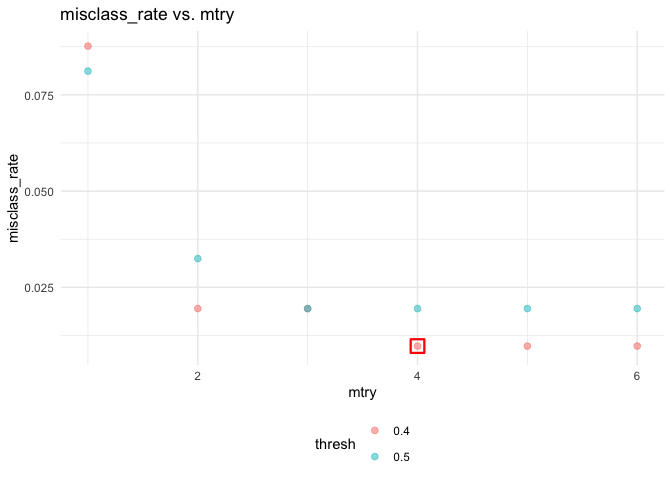

```r
plot_grid(rf_output$accuracy_df, val_measure = "misclass_rate", tp1 = "mtry", tp2 = "thresh")
```

```r
# Check the predictions of the model with the lowest misclass rate
best_spec_idx <-which.min(rf_output$accuracy_df$misclass_rate)
rf_fit_predictions <- rf_output$preds %>%
  filter(spec_no == best_spec_idx)
#check_preds
```

### Check the Accuracy of the Best Model

We similarly look at the confusion matrix and the ROC curve to gauge cut-off trade-off.

#### Using A Confusion Matrix

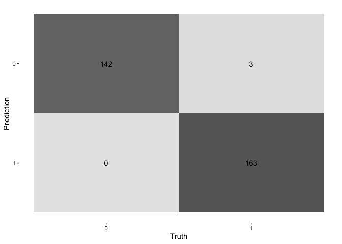

```
## [1] "misclass_rate : 0.00974025974025974"
```

```r
graph_preds(rf_fit_predictions$preds, rf_fit_predictions$y, cm=T, scatter=F)
```